# Intermediate R Introduction

July 6, 2017

## A Quick "About Me"

- Name
- Current Role
- Prior Programming Experience
- Experience with R
- Something Fun?

## Class Outline

- Git and Github for Version Control
- Conditionals and Control Structures
- The 'apply' Family, Functions, and Utilities
- Manipulating Data with dplyr
- Joining Data with dplyr
- Using R Markdown for Reproducible Documents

## Course Mechanics

As with any coding, you will learn MUCH more by doing than by watching

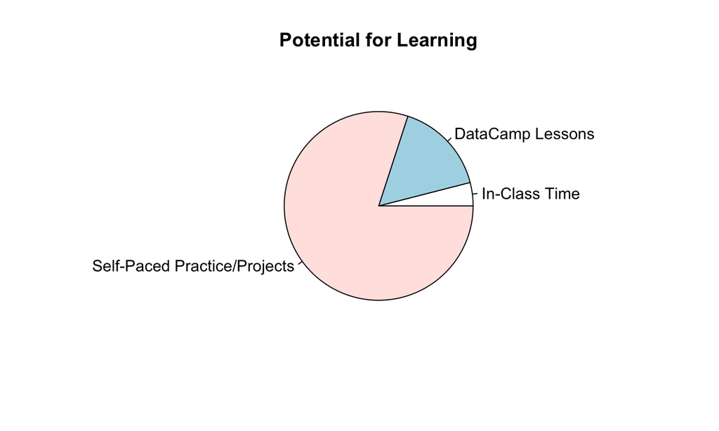

## Course Goals

By the end of this course, you should be able to:

- Perform non-trivial operations through use of loops and conditionals
- Understand the efficiency advantages of using "apply" functions and parallel processing
- Confidently use dplyr to extract information from data frames
- Join data frames together in different ways using dplyr
- Create reproducible markdown documents with embedded R code
- Manage your code using Github repositories

## Getting help

A good rule of thumb is to proceed down this list in order

- Use the *"?"* or *"??"* operators
- Ask the internet
- Google
- StackOverflow
- R-specific sites
- Ask your instructor
- Ask a friend who has expertise
- Use a book

## A Few Other Resources

R is learned by doing; here are some possible avenues for more "doing":

- Other DataCamp courses
- *swirl()*
- Various "Intro to R" or "R Tutorial" sites
- Start a [project](https://marichards.shinyapps.io/abby_and_phil_food_map/)!

## Today's Agenda

- Intro Slides
- Accessing the class Github Repo
- Intro to *swirl()*
- Questions about Week 1 Assignment
- Week 1 In-Class Activity